# Programming basics for Biostatistics 6099

SQL via python

Zhiguang Huo (Caleb)

Tuesday Nov 21st, 2023

# Background

- What is SQL?
  - It’s a programming language used for managing and manipulating relational databases.
- Advantage:
  - Flexibility and Simplicity: The tabular structure makes it easy to understand and navigate.
  - Data Accuracy: Constraints and relations ensure accuracy and consistency of data.
  - Scalability: They can handle large amounts of data and are scalable.
  - Security: Features robust security measures, including access controls and permissions.
  - Data Relationships: Easily handles data relationships, making it ideal for complex queries and data analysis.
- Why we learn SQL?
  - Ubiquitous demand: SQL skills are in high demand across a wide range of industries, including technology, finance, healthcare, retail, and more.
  - Diverse Roles: Proficiency in SQL is a key requirement for many job roles such as database administrators, data analysts, software engineers, business analysts, and more.

# Type of SQL database

- SQL (Relational) Databases:
  - MySQL: One of the most popular open-source relational database management systems.
  - PostgreSQL
  - Microsoft SQL Server
  - Oracle Database
  - SQLite
  - others
- NoSQL (Non-Relational) Databases:
  - MongoDB: A leading NoSQL database that stores data in flexible, JSON-like documents.
  - others
- key difference:
  - SQL: structured table based data model
  - noSQL: flexible data models

# Get started

- object: use python to access mysql
- pre-requisit:
  - mysql
  - mysql-connector

```python
## pip install mysql
## pip install mysql-connector
## pip install mysql-connector-python
import mysql.connector
```

- trouble shooting

https://chat.openai.com/share/18cd0931-81e6-4be4-b3a1-40a73e5232d3

# create a free database (1):

- https://www.clever-cloud.com/
- https://api.clever-cloud.com/v2/sessions/login

[figure not shown]

# create a free database: (2)

select MySQL

- use the free version

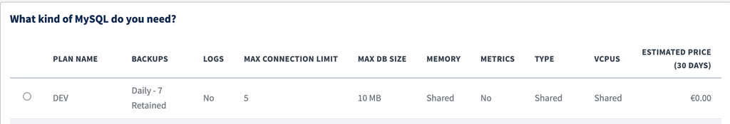

- session information (to be used for python connection)

[figure not shown]

# session information

- These login methods belong to to the instructor.
- **Try to create your own account**.
- Since this is a free database, the DB (database) name is fixed.

```python
MYSQL_ADDON_HOST="bpujmkvwzwgpe3ppgpeg-mysql.services.clever-cloud.com"
MYSQL_ADDON_DB="bpujmkvwzwgpe3ppgpeg"
MYSQL_ADDON_USER="uryjoqt0ohxsfzsn"
MYSQL_ADDON_PORT="3306"
MYSQL_ADDON_PASSWORD='hCkQynjDSNXpzUbpYUjL'
MYSQL_ADDON_URI="mysql://uryjoqt0ohxsfzsn:hCkQynjDSNXpzUbpYUjL@bpujmkvwzwgpe3ppgpeg-mysql.services.clever-cloud.com:3306/bpujmkvwzwgpe3ppgpeg"
```

# login

```python
import mysql.connector

myconn = mysql.connector.connect(
  host=MYSQL_ADDON_HOST,
  user=MYSQL_ADDON_USER,
  password=MYSQL_ADDON_PASSWORD,
  port=MYSQL_ADDON_PORT,
  database=MYSQL_ADDON_DB
)

print(myconn)
```

```
## <mysql.connector.connection.MySQLConnection object at 0x13aa86350>
```

```python
mycursor = myconn.cursor() ## an object to interact with the SQL
print(myconn)
```

```
## <mysql.connector.connection.MySQLConnection object at 0x13aa86350>
```

# Create a database

- Create a database
  - This doesn’t work in our class demonstration
  - Since we’re using the free version
  - The dataset name is given

```
myconn = mysql.connector.connect(
  host=MYSQL_ADDON_HOST,
  user=MYSQL_ADDON_USER,
  password=MYSQL_ADDON_PASSWORD,
  port=MYSQL_ADDON_PORT,
  database=MYSQL_ADDON_DB
)
mycursor = myconn.cursor()
mycursor.execute("CREATE DATABASE mydatabase")
```

# Show existing database

```python
myconn = mysql.connector.connect(
  host=MYSQL_ADDON_HOST,
  user=MYSQL_ADDON_USER,
  password=MYSQL_ADDON_PASSWORD,
  port=MYSQL_ADDON_PORT,
  database=MYSQL_ADDON_DB
)

mycursor = myconn.cursor()
mycursor.execute("SHOW DATABASES")
for db_name in mycursor:
   print(db_name)
```

```
## (bytearray(b'bpujmkvwzwgpe3ppgpeg'),)
## (bytearray(b'information_schema'),)
```

# Create a table

```python
myconn = mysql.connector.connect(
  host=MYSQL_ADDON_HOST,
  user=MYSQL_ADDON_USER,
  password=MYSQL_ADDON_PASSWORD,
  port=MYSQL_ADDON_PORT,
  database=MYSQL_ADDON_DB
)
mycursor = myconn.cursor()

mycursor.execute("CREATE TABLE customers (name VARCHAR(255), address VARCHAR(255))")
```

- table name: customers
  - variable: name (type character)
  - variable: address (type character)

# Show existing tables

```python
myconn = mysql.connector.connect(
  host=MYSQL_ADDON_HOST,
  user=MYSQL_ADDON_USER,
  password=MYSQL_ADDON_PASSWORD,
  port=MYSQL_ADDON_PORT,
  database=MYSQL_ADDON_DB
)
mycursor = myconn.cursor()
mycursor.execute("SHOW TABLES")
for table_name in mycursor:
   print(table_name)
```

```
## (bytearray(b'customers'),)
## (bytearray(b'products'),)
## (bytearray(b'users'),)
```

# Delete a table (1)

```python
myconn = mysql.connector.connect(
  host=MYSQL_ADDON_HOST,
  user=MYSQL_ADDON_USER,
  password=MYSQL_ADDON_PASSWORD,
  port=MYSQL_ADDON_PORT,
  database=MYSQL_ADDON_DB
)
mycursor = myconn.cursor()
mycursor.execute("DROP TABLE customers")
mycursor.execute("SHOW TABLES")
for table_name in mycursor:
   print(table_name)
```

```
## (bytearray(b'products'),)
## (bytearray(b'users'),)
```

# Delete a table (2)

- delete a table only if that exists

```python
myconn = mysql.connector.connect(
  host=MYSQL_ADDON_HOST,
  user=MYSQL_ADDON_USER,
  password=MYSQL_ADDON_PASSWORD,
  port=MYSQL_ADDON_PORT,
  database=MYSQL_ADDON_DB
)
mycursor = myconn.cursor()
sql = "DROP TABLE IF EXISTS customers"
mycursor.execute(sql)
mycursor.execute("SHOW TABLES")
for table_name in mycursor:
   print(table_name)
```

```
## (bytearray(b'products'),)
## (bytearray(b'users'),)
```

# Create a table with auto increasing ID as key

```python
myconn = mysql.connector.connect(
  host=MYSQL_ADDON_HOST,
  user=MYSQL_ADDON_USER,
  password=MYSQL_ADDON_PASSWORD,
  port=MYSQL_ADDON_PORT,
  database=MYSQL_ADDON_DB
)
mycursor = myconn.cursor()
mycursor.execute("CREATE TABLE customers (id INT AUTO_INCREMENT PRIMARY KEY, name VARCHAR(255), address VARCHAR(255))")
mycursor.execute("SHOW TABLES")
for table_name in mycursor:
   print(table_name)
```

```
## (bytearray(b'customers'),)
## (bytearray(b'products'),)
## (bytearray(b'users'),)
```

# Add an entry into the database

```python
myconn = mysql.connector.connect(
  host=MYSQL_ADDON_HOST,
  user=MYSQL_ADDON_USER,
  password=MYSQL_ADDON_PASSWORD,
  port=MYSQL_ADDON_PORT,
  database=MYSQL_ADDON_DB
)
mycursor = myconn.cursor()
# sql = "INSERT INTO customers (name, address) VALUES ('John', 'Highway21')"
# mycursor.execute(sql)
sql = "INSERT INTO customers (name, address) VALUES (%s, %s)"
val = ("John", "Highway 21")
mycursor.execute(sql, val)
myconn.commit() ## commit changes to the database
print(mycursor.rowcount, "record inserted.")
```

```
## 1 record inserted.
```

# Print all content of a table

```python
myconn = mysql.connector.connect(
  host=MYSQL_ADDON_HOST,
  user=MYSQL_ADDON_USER,
  password=MYSQL_ADDON_PASSWORD,
  port=MYSQL_ADDON_PORT,
  database=MYSQL_ADDON_DB
)
mycursor = myconn.cursor()
mycursor.execute("SELECT * FROM customers")
myresult = mycursor.fetchall()
for x in myresult:
  print(x)
```

```
## (1, 'John', 'Highway 21')
```

# Add multiple entries into the database

```python
myconn = mysql.connector.connect(
  host=MYSQL_ADDON_HOST,
  user=MYSQL_ADDON_USER,
  password=MYSQL_ADDON_PASSWORD,
  port=MYSQL_ADDON_PORT,
  database=MYSQL_ADDON_DB
)
mycursor = myconn.cursor()

sql = "INSERT INTO customers (name, address) VALUES (%s, %s)"
val = [
  ('Peter', 'Lowstreet 4'),
  ('Amy', 'Apple st 652'),
  ('Hannah', 'Mountain 21'),
  ('Michael', 'Valley 345'),
  ('Sandy', 'Ocean blvd 2'),
  ('Betty', 'Green Grass 1'),
  ('Richard', 'Sky st 331'),
  ('Susan', 'One way 98'),
  ('Vicky', 'Yellow Garden 2'),
  ('Ben', 'Park Lane 38'),
  ('William', 'Central st 954'),
  ('Chuck', 'Main Road 989'),
  ('Viola', 'Sideway 1633')
]

mycursor.executemany(sql, val)

myconn.commit()

print(mycursor.rowcount, "was inserted.")
```

```
## 13 was inserted.
```

# Print all content of a table

```python
myconn = mysql.connector.connect(
  host=MYSQL_ADDON_HOST,
  user=MYSQL_ADDON_USER,
  password=MYSQL_ADDON_PASSWORD,
  port=MYSQL_ADDON_PORT,
  database=MYSQL_ADDON_DB
)
mycursor = myconn.cursor()
mycursor.execute("SELECT * FROM customers")
myresult = mycursor.fetchall()
for x in myresult:
  print(x)
```

```
## (1, 'John', 'Highway 21')
## (2, 'Peter', 'Lowstreet 4')
## (3, 'Amy', 'Apple st 652')
## (4, 'Hannah', 'Mountain 21')
## (5, 'Michael', 'Valley 345')
## (6, 'Sandy', 'Ocean blvd 2')
## (7, 'Betty', 'Green Grass 1')
## (8, 'Richard', 'Sky st 331')
## (9, 'Susan', 'One way 98')
## (10, 'Vicky', 'Yellow Garden 2')
## (11, 'Ben', 'Park Lane 38')
## (12, 'William', 'Central st 954')
## (13, 'Chuck', 'Main Road 989')
## (14, 'Viola', 'Sideway 1633')
```

# Print head content of a table

```python
myconn = mysql.connector.connect(
  host=MYSQL_ADDON_HOST,
  user=MYSQL_ADDON_USER,
  password=MYSQL_ADDON_PASSWORD,
  port=MYSQL_ADDON_PORT,
  database=MYSQL_ADDON_DB
)
mycursor = myconn.cursor()
mycursor.execute("SELECT * FROM customers LIMIT 5")
myresult = mycursor.fetchall()
for x in myresult:
  print(x)
```

```
## (1, 'John', 'Highway 21')
## (2, 'Peter', 'Lowstreet 4')
## (3, 'Amy', 'Apple st 652')
## (4, 'Hannah', 'Mountain 21')
## (5, 'Michael', 'Valley 345')
```

# Print head content of a table with offset

```python
myconn = mysql.connector.connect(
  host=MYSQL_ADDON_HOST,
  user=MYSQL_ADDON_USER,
  password=MYSQL_ADDON_PASSWORD,
  port=MYSQL_ADDON_PORT,
  database=MYSQL_ADDON_DB
)
mycursor = myconn.cursor()
mycursor.execute("SELECT * FROM customers LIMIT 5 OFFSET 2")
myresult = mycursor.fetchall()
for x in myresult:
  print(x)
```

```
## (3, 'Amy', 'Apple st 652')
## (4, 'Hannah', 'Mountain 21')
## (5, 'Michael', 'Valley 345')
## (6, 'Sandy', 'Ocean blvd 2')
## (7, 'Betty', 'Green Grass 1')
```

# Select certain columns in a table

```python
myconn = mysql.connector.connect(
  host=MYSQL_ADDON_HOST,
  user=MYSQL_ADDON_USER,
  password=MYSQL_ADDON_PASSWORD,
  port=MYSQL_ADDON_PORT,
  database=MYSQL_ADDON_DB
)
mycursor = myconn.cursor()
mycursor.execute("SELECT address, name FROM customers")
myresult = mycursor.fetchall()
for x in myresult:
  print(x)
```

```
## ('Highway 21', 'John')
## ('Lowstreet 4', 'Peter')
## ('Apple st 652', 'Amy')
## ('Mountain 21', 'Hannah')
## ('Valley 345', 'Michael')
## ('Ocean blvd 2', 'Sandy')
## ('Green Grass 1', 'Betty')
## ('Sky st 331', 'Richard')
## ('One way 98', 'Susan')
## ('Yellow Garden 2', 'Vicky')
## ('Park Lane 38', 'Ben')
## ('Central st 954', 'William')
## ('Main Road 989', 'Chuck')
## ('Sideway 1633', 'Viola')
```

# filter a table (1)

- filter by a specific item

```python
myconn = mysql.connector.connect(
  host=MYSQL_ADDON_HOST,
  user=MYSQL_ADDON_USER,
  password=MYSQL_ADDON_PASSWORD,
  port=MYSQL_ADDON_PORT,
  database=MYSQL_ADDON_DB
)
mycursor = myconn.cursor()
# sql = "SELECT * FROM customers WHERE address = 'Yellow Garden 2'"
# mycursor.execute(sql)
sql = "SELECT * FROM customers WHERE address = %s"
adr = ("Yellow Garden 2", )
mycursor.execute(sql, adr)

myresult = mycursor.fetchall()
for x in myresult:
  print(x)
```

```
## (10, 'Vicky', 'Yellow Garden 2')
```

# filter a table (2)

- filter by a pattern

```python
myconn = mysql.connector.connect(
  host=MYSQL_ADDON_HOST,
  user=MYSQL_ADDON_USER,
  password=MYSQL_ADDON_PASSWORD,
  port=MYSQL_ADDON_PORT,
  database=MYSQL_ADDON_DB
)
mycursor = myconn.cursor()
sql = "SELECT * FROM customers WHERE address LIKE '%way%'"
mycursor.execute(sql)

myresult = mycursor.fetchall()
for x in myresult:
  print(x)
```

```
## (1, 'John', 'Highway 21')
## (9, 'Susan', 'One way 98')
## (14, 'Viola', 'Sideway 1633')
```

# Sort a table

- ascending order (default)

```python
myconn = mysql.connector.connect(
  host=MYSQL_ADDON_HOST,
  user=MYSQL_ADDON_USER,
  password=MYSQL_ADDON_PASSWORD,
  port=MYSQL_ADDON_PORT,
  database=MYSQL_ADDON_DB
)

mycursor = myconn.cursor()
sql = "SELECT * FROM customers ORDER BY name"
#sql = "SELECT * FROM customers ORDER BY name DESC" ## descending order
mycursor.execute(sql)

myresult = mycursor.fetchall()
for x in myresult:
  print(x)
```

```
## (3, 'Amy', 'Apple st 652')
## (11, 'Ben', 'Park Lane 38')
## (7, 'Betty', 'Green Grass 1')
## (13, 'Chuck', 'Main Road 989')
## (4, 'Hannah', 'Mountain 21')
## (1, 'John', 'Highway 21')
## (5, 'Michael', 'Valley 345')
## (2, 'Peter', 'Lowstreet 4')
## (8, 'Richard', 'Sky st 331')
## (6, 'Sandy', 'Ocean blvd 2')
## (9, 'Susan', 'One way 98')
## (10, 'Vicky', 'Yellow Garden 2')
## (14, 'Viola', 'Sideway 1633')
## (12, 'William', 'Central st 954')
```

# Delete a record in a table (1)

```python
myconn = mysql.connector.connect(
  host=MYSQL_ADDON_HOST,
  user=MYSQL_ADDON_USER,
  password=MYSQL_ADDON_PASSWORD,
  port=MYSQL_ADDON_PORT,
  database=MYSQL_ADDON_DB
)

mycursor = myconn.cursor()
sql = "DELETE FROM customers WHERE address = 'Mountain 21'"
mycursor.execute(sql)
myconn.commit()
print(mycursor.rowcount, "record(s) deleted")
```

```
## 1 record(s) deleted
```

# Delete a record in a table (2)

```python
myconn = mysql.connector.connect(
  host=MYSQL_ADDON_HOST,
  user=MYSQL_ADDON_USER,
  password=MYSQL_ADDON_PASSWORD,
  port=MYSQL_ADDON_PORT,
  database=MYSQL_ADDON_DB
)

mycursor = myconn.cursor()
sql = "DELETE FROM customers WHERE address = %s"
adr = ("Yellow Garden 2", )
mycursor.execute(sql, adr)
myconn.commit()
print(mycursor.rowcount, "record(s) deleted")
```

```
## 1 record(s) deleted
```

# Update a record/entry (1)

```python
myconn = mysql.connector.connect(
  host=MYSQL_ADDON_HOST,
  user=MYSQL_ADDON_USER,
  password=MYSQL_ADDON_PASSWORD,
  port=MYSQL_ADDON_PORT,
  database=MYSQL_ADDON_DB
)

mycursor = myconn.cursor()

sql = "UPDATE customers SET address = 'Canyon 123' WHERE address = 'Valley 345'"

mycursor.execute(sql)

myconn.commit()

print(mycursor.rowcount, "record(s) affected")
```

```
## 1 record(s) affected
```

# Update a record/entry (2)

```python
myconn = mysql.connector.connect(
  host=MYSQL_ADDON_HOST,
  user=MYSQL_ADDON_USER,
  password=MYSQL_ADDON_PASSWORD,
  port=MYSQL_ADDON_PORT,
  database=MYSQL_ADDON_DB
)
mycursor = myconn.cursor()

sql = "UPDATE customers SET address = %s WHERE address = %s"
val = ("Valley 345", "Canyon 123")
mycursor.execute(sql, val)

myconn.commit()
print(mycursor.rowcount, "record(s) affected")
```

```
## 1 record(s) affected
```

# merge two tables (create left table)

- left table:

```python
myconn = mysql.connector.connect(
  host=MYSQL_ADDON_HOST,
  user=MYSQL_ADDON_USER,
  password=MYSQL_ADDON_PASSWORD,
  port=MYSQL_ADDON_PORT,
  database=MYSQL_ADDON_DB
)

mycursor = myconn.cursor()
sql = "DROP TABLE IF EXISTS users"
mycursor.execute(sql)

mycursor.execute("CREATE TABLE users (id INT(255), name VARCHAR(255), fav INT(255))")
sql = "INSERT INTO users (id, name, fav) VALUES (%s, %s, %s)"
val = [
    (1, 'John', 154),
    (2, 'Peter', 154),
    (3, 'Amy', 155),
    (4, 'Hannah', 167),
    (5, 'Michael', 189)
]

mycursor.executemany(sql, val)
myconn.commit()
print(mycursor.rowcount, "was inserted.")
```

```
## 5 was inserted.
```

```python
mycursor.execute("SELECT * FROM users LIMIT 5")
myresult = mycursor.fetchall()

for x in myresult:
  print(x)
```

```
## (1, 'John', 154)
## (2, 'Peter', 154)
## (3, 'Amy', 155)
## (4, 'Hannah', 167)
## (5, 'Michael', 189)
```

# merge two tables (create right table)

- right table:

```python
myconn = mysql.connector.connect(
  host=MYSQL_ADDON_HOST,
  user=MYSQL_ADDON_USER,
  password=MYSQL_ADDON_PASSWORD,
  port=MYSQL_ADDON_PORT,
  database=MYSQL_ADDON_DB
)

mycursor = myconn.cursor()
sql = "DROP TABLE IF EXISTS products"
mycursor.execute(sql)

mycursor.execute("CREATE TABLE products (id INT(255), name VARCHAR(255))")

sql = "INSERT INTO products (id, name) VALUES (%s, %s)"
val = [
    (154, 'Chocolate Heaven'),
    (155, 'Tasty Lemons'),
    (156, 'Vanilla Dreams')
]

mycursor.executemany(sql, val)
myconn.commit()
print(mycursor.rowcount, "was inserted.")
```

```
## 3 was inserted.
```

```python
mycursor.execute("SELECT * FROM products LIMIT 5")
myresult = mycursor.fetchall()

for x in myresult:
  print(x)
```

```
## (154, 'Chocolate Heaven')
## (155, 'Tasty Lemons')
## (156, 'Vanilla Dreams')
```

# merge (inner) (1)

```python
myconn = mysql.connector.connect(
  host=MYSQL_ADDON_HOST,
  user=MYSQL_ADDON_USER,
  password=MYSQL_ADDON_PASSWORD,
  port=MYSQL_ADDON_PORT,
  database=MYSQL_ADDON_DB
)
mycursor = myconn.cursor()

sql = "SELECT * \
  FROM users \
  INNER JOIN products ON users.fav = products.id"
mycursor.execute(sql)

myresult = mycursor.fetchall()
for x in myresult:
  print(x)
```

```
## (1, 'John', 154, 154, 'Chocolate Heaven')
## (2, 'Peter', 154, 154, 'Chocolate Heaven')
## (3, 'Amy', 155, 155, 'Tasty Lemons')
```

# merge (inner) (2)

```python
myconn = mysql.connector.connect(
  host=MYSQL_ADDON_HOST,
  user=MYSQL_ADDON_USER,
  password=MYSQL_ADDON_PASSWORD,
  port=MYSQL_ADDON_PORT,
  database=MYSQL_ADDON_DB
)
mycursor = myconn.cursor()

sql = "SELECT \
  users.name AS user, \
  products.name AS favorite \
  FROM users \
  INNER JOIN products ON users.fav = products.id"
mycursor.execute(sql)

myresult = mycursor.fetchall()
for x in myresult:
  print(x)
```

```
## ('John', 'Chocolate Heaven')
## ('Peter', 'Chocolate Heaven')
## ('Amy', 'Tasty Lemons')
```

# Reference

https://www.w3schools.com/python/python_mysql_create_table.asp